# marky Documentation

lehmann7

2021-09-09

> **Abstract** – `marky` is a preprocessor for Markdown using Python. `marky` is inspired by [pandoc](https://www.pandoc.org/), [RMarkdown](https://rmarkdown.rstudio.com/), [Quarto](https://quarto.org/). This document is created using `marky` (Version 0.1) and contains examples which illustrate the generation of document content for `html` and `pdf` and the dynamical adjustment of Markdown text during preprocessing based on `python` code. The full raw `marky` source code of this documentation appended at the end. The `marky` source code of this document can be read here. For more information please refer to the [`marky` repository](https://github.com/lehmann7/marky), `marky` quickstart or the simple `marky` example.

# 1 Introduction

`marky` is a Markdown preprocessor which transforms a Markdown document using python. `marky` implements new markup which controls the execution of python code and the generation and manipulation of Markdown text. The `marky` quickstart can be found here and a very simple `marky` example can be found here.

`marky` only depends on `pandoc` and `pyyaml`. `pandoc` is used for rendering the Markdown into `html` and `pdf`. `pandoc` supports various Markdown extensions allowing for scientific writing using equations, figures, tables, citations and corresponding referencing mechanism for the latter. `pyyaml` is used for parsing meta data in the front matter of the Markdown text if it is present.

Workflow for creating `html` or `pdf` using `marky`

1. user writes a Markdown text file and places it in `md/*.md` directory with the extension `.md`. the Markdown text contains special `marky` markup which executes python code and manipulates the Markdown text.
2. `marky` transforms the files in `md/*.md` into regular Markdown text and places the transformed files in `build/*.md`. The transformed text only contains regular Markdown, and placeholders for format dependent output for `html` and `pdf`.
3. before rendering `marky` replaces placeholders for format dependent output with content creating a temporary file which only contains regular Markdown text for `html` and `pdf` documents according to `pandoc` Markdown specification.
4. the regular Markdown text in the files `build/*.md` is rendered into `html` and `pdf` using `pandoc`.

# 2 Related Work

For scientific reporting and writing usually typesetting systems or complicted WYSIWYG editors are used. In order to simplify the writing different approaches and frameworks have been developed.

- [`pandoc`](https://www.pandoc.org/),
- [RMarkdown](https://rmarkdown.rstudio.com/)
- [Quarto](https://quarto.org/)
- [Scientific Markdown](https://jaantollander.com/post/scientific-writing-with-markdown/)
- [Technical `pandoc`](https://lee-phillips.org/panflute-gnuplot/)

Where as RMarkdown and Quarto are integrated frameworks, which additionally depend on `knitr`, `RStudio`, `Jupyter`, `marky` depends on `pandoc` and `pyyaml` only. `marky` natively only supports executable python code blocks, however, other languages can be executed using wrappers, which are available for other languages.

# 3 `marky` Features

`marky` implements following features using an simple Markdown-style syntax.

1. read Markdown meta data from front matter, see Section 6.1

```markdown
    ---
        <key>: <value>
    ---
```

2. execute and hide/show python code blocks inside Markdown text, see Section 6.2

````markdown
    ```!
        <python_code_shown>
    ```

    ```!!
        <python_code_hidden>
    ```
````

3. generate Markdown text using python code, see Section 6.3

````markdown
    ```!
        _("<markdown_text>")
        __("""
            <markdown_text>
            <markdown_text>
            <markdown_text>
        """)
    ```
````

4. format output of python variables into Markdown text, see Section 6.4

```markdown
    Output into text: `!<python_variable>`
```

5. output the result of python expressions into Markdown text, see Section 6.5

```markdown
    Output into text: `!<python_expression>`
```

6. include Markdown text, make dependencies and forward meta data, see Section 6.6 and 6.7.

```markdown
    !!! include_file.mdi
```

7. format links in `html` and `pdf` documents for referencing external documents of the same format, see Section 6.8.

```markdown
    [Format Link to html/pdf document](path/to/file.???)
```

8. use format codes in order to inject format specific code in `html` and `pdf` documents, see Section 6.9.

````markdown
    ```!
        class myfmt(fmtcode):
            def html(self):
                _("<HTML_CODE>")
                return """
                    <MORE_CODE>
                    <MORE_CODE>
                    <MORE_CODE>
                """
            def pdf(self):
                __("""
                    {TEX_CODE}
                    {TEX_CODE}
                    {TEX_CODE}
                """)
        fmtc = myfmt()
    ```

    Format dependent output: `!fmtc()`
````

# 4 Scientific Writing in Markdown

[Markdown](https://pandoc.org/MANUAL.html#pandocs-markdown) is a markup language for technical writing, with emphasis on readability. Markdown can be rendered in many formats including `html` and `pdf` by using [`pandoc`](https://pandoc.org/) for example.

Using various Markdown extensions of `pandoc` a sufficient structure for writing scientific documents can be reflected using Markdown syntax. `marky` uses the following `pandoc` Markdown extensions.

- parsing extensions
  - all_symbols_escapable
  - intraword_underscores
  - escaped_line_breaks
  - space_in_atx_header
  - lists_without_preceding_blankline
- styling extensions
  - inline_code_attributes
  - strikeout
- structuring extensions
  - yaml_metadata_block
  - pipe_tables
  - line_blocks
  - implicit_figures
  - abbreviations
  - inline_notes
- code injection
  - raw_html
  - raw_tex

`pandoc` supports [equations](https://pandoc.org/MANUAL.html#extension-tex_math_dollars) rendered inline and single-line in tex-style using `$...$` and `$$...$$`, [bibliography](https://pandoc.org/MANUAL.html#citations) using the `--citeproc` option, [section numbering](https://pandoc.org/MANUAL.html#extension-header_attributes) using the `--number-sections` option and [table of contents](https://pandoc.org/MANUAL.html#option--toc) using the `--table-of-contents` option.

`pandoc` supports [`xnos`](https://github.com/tomduck/pandoc-xnos) filters for referencing document content like [figures](https://github.com/tomduck/pandoc-fignos#usage), [equations](https://github.com/tomduck/pandoc-eqnos#usage), [tables](https://github.com/tomduck/pandoc-tablenos#usage), [sections](https://github.com/tomduck/pandoc-secnos#usage) by using the `--filter pandoc-xnos` option. `xnos` integrates clever references, which means “Fig.”, “Sec.”, “Eq.” and “Tab.” are added automatically to the corresponding element. If the prefix is to be omitted, the reference can be written as `!@ref:label`.

**Example**

```markdown
## Referenced Section {#sec:label}

This is a reference to @sec:label.

![This is the caption](data:…
UhEUgAAAAUAAAAFCAYAAACNbyblAAAAHElEQVQI12P4//8/w38GIAXDIBKE0DH
xgljNBAAO9TXL0Y4OHwAAAABJRU5ErkJggg==){#fig:label}

This is a reference to @fig:label.

A  |B  |C  |D
---|---|---|---
000|111|444|555
222|333|666|777

Table: This is the caption {#tbl:label}

This is a reference to @tbl:label.

$$\mbox{e}^{\mbox{i}\pi}+1=0$${#eq:label}

This is a reference to @eq:label.

This is a citation [@Muller1993].
```

The file `marky.bib` is specified in the meta data in the front matter of the Markdown text and contains the following article.

```
@article{Muller1993,
    author  = {Peter Muller},
    title   = {The title of the work},
    journal = {The name of the journal},
    year    = {1993},
    number  = {2},
    pages   = {201-213},
    month   = {7},
    note    = {An optional note},
    volume  = {4}
}
```

**Output**

## 4.1 Referenced Section

This is a reference to Section 4.1.

Figure 1: This is the caption

This is a reference to Fig. 1.

Table 1: This is the caption.

| A | B | C | D |
| --- | --- | --- | --- |
| 000 | 111 | 444 | 555 |
| 222 | 333 | 666 | 777 |

This is a reference to Table 1.

e<sup>*i**π*</sup> + 1 = 0(1)

This is a reference to Eq. 1.

This is a citation (Muller 1993).

# 5 `marky.py` Command-Line Usage

## 5.1 `marky.py` Script Usage

`marky` is supplied as a single-file script which contains the `marky` `Makefile` as well as the `marky` documentation `marky.md`, `marky.mdi` and `marky.bib`.

After downloading `marky.py` the script needs to be placed in a project working directory `working_dir`. The script can be invoked using a python interpreter `python` marky.py or it can be executed using a shell:

```bash
> cd working_dir
> chmod +x marky.py
> ./marky.py
```

A new project is initialized in the `working_dir` using the `--init` option. `marky` creates a directory tree for the project, which is explained in detail in Section 5.2. The `marky` `Makefile` and documentation `marky.md`, `marky.mdi` and `marky.bib` are auto-generated and placed inside the subdirs `md/` and `data/` in `working_dir` accordingly.

```bash
> cd working_dir
> ./marky.py --init
WRITE ./Makefile
WRITE ./md/marky.md
WRITE ./md/marky.mdi
WRITE ./data/marky.bib
USAGE
1. `make help`
2. `make all-html httpd`
3. `make all-pdf`
```

`marky` renders the documentation using `pandoc` into `html` and `pdf` using `make all`. `html` and `pdf` documents can be rendered after installing the dependencies `python-pyyaml`, `pandoc` and `pandoc-xnos` (`pandoc-fignos`, `pandoc-secnos`, `pandoc-eqnos`, `pandoc-tablenos`). The details are shown in the `Makefile` help message in Section 5.3.

## 5.2 `marky` Project Structure

A `marky` project has the following structure, which is auto-generated in the project directory `working_dir` after invocation of marky.py `--init`.

```
# PROJECT TREE
##############
#
# working_dir
# |
# |- marky.py            - marky executable
# |- Makefile        (*) - marky Makefile
# |
# |- md/             (*) - user Markdown dir
# |  |- marky.md(i)  (*) - marky documentation text
# |  |- *.md             - user Markdown text files
# |  |- *.mdi            - user Markdown include files
# |
# |- data/           (*) - pandoc resource directory
# |  |- marky.bib    (*) - marky documentation bib
# |  |- *.bib            - user bibliography files
# |  |- *.png/jpg        - user image files
# |  |- ...                etc...
# |
# |- build/          (*) - build Markdown dir
# |  |- *.md         (*) - preprocessed Markdown text
# |  |- *.md.mk      (*) - Makefile dependencies
# |  |- *.html.md    (*) - linked Markdown for html format
# |  |- *.pdf.md     (*) - linked Markdown for pdf format
# |
# |- html/           (*) - rendered html dir
# |- pdf/            (*) - rendered pdf dir
#
# (*) directories/files are auto-generated using
#    `./marky.py --init` and `make all´
#
```

By invoking `make all` all files `md/*.md` are transformed into corresponding `html/*.html` and `pdf/*.pdf` files. By invoking `make httpd` a python web server is started in `html/`.

All user-generated project content goes into `md/*.md(i)` for Markdown text and Markdown include files and `data/*` for images, bibliography, videos, html frames, etc…

**ATTENTION:** The files in the directories `build/*.md` are **auto-generated**. All user-generated content `*.md` and `*.mdi` has to be placed inside the directory `md/`. Invoking `make clean` will delete all files in `html/`, `build/` and `pdf/`.

## 5.3 `marky` Makefile Usage

By running `make` or `make help` in the project `working_dir` the `Makefile` help is shown.

```
#
# marky HELP
############
#
# TARGETS
#
# Tools:
#  * help      - show this message
#  * tree      - show the project tree
#  * cheat     - show the marky *Cheat Sheet*
#  * httpd     - run python -m httpd.server in `html/`
#  * scan      - build make dependencies and targets
#
# Build:
#  * all       - alias: `make all-html all-pdf`
#  * all-html  - render html (`build/*.html.md`->`html/*.html`)
#  * all-pdf   - render pdf (`build/*.pdf.md`->`pdf/*.pdf`)
#  * clean     - delete: `build/*`, `html/*`, `pdf/*`
#
# Debug:
#  * all-mk    - depend: `md/*.md`->`build/*.md.mk`
#  * all-md    - marky: `md/*.md`->`build/*.md`
#  * all-link  - link (`build/*.md`->`build/*.html.md/pdf`)
#
# Dependencies:
#  * pandoc >= 2.10
#  * pip install pandoc-fignos
#  * pip install pandoc-eqnos
#  * pip install pandoc-secnos
#  * pip install pandoc-tablenos
#  * pip install pandoc-xnos
#  * pip install pyyaml
#
# ATTENTION
#  files in `build/*.md` and `html/*.html` are auto-generated.
#  user files `*.md(i)` have to be placed in `md/*.md(i)`.
#  `make clean` deletes all files in `build/`, `html/` and `pdf/`.
#
# EXAMPLE
#  1. run `make all-html httpd`:
#     * transform `md/*.md`->`html/*.html`
#     * start a python httpd server in `html`
#  2. run `make all-pdf`
#     * transform `md/*.md`->`pdf/*.pdf`
#
```

## 5.4 `marky` Cheat Sheet

By running `make cheat` in the project `working_dir` the `marky` cheat sheet is shown, which presents a quick overview of `marky` special markup for execution of python code and manipulation of Markdown text, according to the features describes in Section 3.

````
#
# marky CHEAT SHEET
###################
#
# CODE-BLOCK
#
#  ```!
#  print("The code is shown in the document,")
#  print("but printed text is shown in console.")
#  _("This text is inserted into Markdown", _)
#  _(_, "output and appended to prev line.")
#  _(1, 2, 3, [4, 5,], "a", "b", sep=", ")
#  __("""
#     * This is cropped and shifted.
#     * This is cropped and shifted.
#     * This is cropped and shifted.
#  """, crop=True, shift=)
#  ```
#
#  ```!!
#  print("The code is hidden in the document,")
#  print("but printed text is shown in console.")
#  import sys
#  sys.path.append(".")
#  import mymodule
#  new_vars = {"a": 1, "b": 2}
#  globals().update(new_vars)
#  ```
#
#
# FORMATTED OUTPUT
#
#  ```!!
#  value = float(1.2345)
#  ```
#  The number `!value` is not formatted.
#  The number 1.2345 is not formatted.
#
#  The number `!value:.2f` is formatted.
#  The number 1.23 is formatted.
#
#  This `\!<variable>` is not parsed.
#
#
# INLINE-EXPRESSION
#
#  This is a Paragraph with an `!<expression>`.
#  This `\!<expression>` is not parsed.
#
#  The alphabet: `![chr(ord("A")+i for i in range(7)]`.
#  The alphabet: ['A', 'B', 'C', 'D', 'E', 'F', 'G'].
#
#  A nice list: `!", ".join(list(range(1, 11)))`.
#  A nice list: 1, 2, 3, 4, 5, 6, 7, 8, 9, 10.
#
#
# META DATA
#
#  ---
#  title: Document
#  date: Today
#  author: Name
#  link-citations: true
#  bibliography: bibl.bib
#  fontsize--pdf: 11pt
#  fontsize--html: 10pt
#  header-includes--pdf: >
#     \usepackage{...}
#     \usepackage{...}
#  header-includes--html: >
#     <script ...>
#     <link ...>
#     <style ...>
#  xnos-cleveref: true
#  xnos-capitalise: true
#  -hidden_field: text
#  ---
#
#
# INCLUDE-STATEMENT
#
#  !!! path/incl.mdi FLAGS
#  \!!! This is not parsed as include statement.
#
# Flags:
#  * aux      only Makefile dependency, no include
#  * nodep    include without Makefile dependency
#  * raw      do not parse file, include as-is
#  * nometa   ignore and skip all meta data
#  * nobody   ignore and skip Markdown body
#  * nomarky  no processing of marky markup
#  * code     include only the hidden code blocks
#  * code!    include only code, but all code blocks
#  * #+N      increase level of ATX headings by N
#  * >>N      increase indentation level by N tabs
#  * >N       increase indentation level by N spaces
#
#
# FORMAT LINK
#
#  [Link to Document](path/to/file.html)
#  [Link to Document](path/to/file.pdf)
#  [Format Link to Document](path/to/file.???)
#  This is not parsed as format link .\???
#
#
# FORMAT CODE
#
#   ```!
#   test1 = fmtcode(html="HTML", pdf="PDF")
#   class Test2(fmtcode):
#       def html(self):
#           __("""
#               This is HTML2!
#               This is HTML2!
#               This is HTML2!
#           """)
#       def pdf(self):
#           return """
#               This is \{PDF2\}!
#               This is \{PDF2\}!
#               This is \{PDF2\}!
#           """
#   test2 = Test2()
#   ```
#   Run Format Code `!test1()` and `!test2()`.
#   `\!test1()` and `\!test2()` are not parsed.
#
#   ```!
#       _(test1())
#       _(test2())
#   ```
#
````

# 6 `marky` Preprocessor Markup

## 6.1 Yaml Meta Data in Front Matter

**Example**

```yaml
---
title: marky Documentation
date: `Date`
author: `Author`
link-citations: True
bibliography: data/marky.bib
header-includes--pdf: >
  \hypersetup{
  colorlinks=false,
  allbordercolors={0 0 0},
  pdfborderstyle={/S/U/W 1}}
header-includes--html: >
  <style>* { box-sizing: border-box; }</style>
xnos-cleveref: True
xnos-capitalise: True
fontsize: 11pt
version: 0.1
figsize: [10, 8]
figdpi: 300

---
```

The meta data fields [`title`, `date`, `author`](https://pandoc.org/MANUAL.html#metadata-variables), [`link-citations`](https://pandoc.org/MANUAL.html#other-relevant-metadata-fields), [`bibliography`](https://pandoc.org/MANUAL.html#citation-rendering) and [`header-includes`](https://pandoc.org/MANUAL.html#variables-set-automatically) are processed by `pandoc` during document rendering. `fontsize` adjusts the font size in [`html`](https://pandoc.org/MANUAL.html#variables-for-html) and [`pdf`](https://pandoc.org/MANUAL.html#variables-for-latex) documents. The `header-includes` field is used for underlining links in `pdf` and `html` documents. The `xnos-cleveref` and `xnos-capitalise` fields are used by the [`pandoc-xnos`](https://github.com/tomduck/pandoc-xnos) extensions for referencing [figures](https://github.com/tomduck/pandoc-fignos#customization), [tables](https://github.com/tomduck/pandoc-tablenos#customization), [sections](https://github.com/tomduck/pandoc-secnos#customization) and [equations](https://github.com/tomduck/pandoc-eqnos#customization).

The field `header-includes` ends with `--pdf` and `--html`, which specifies corresponding options for generation of `pdf` and `html` documents. During make, `marky` scans all meta data fields, and fields which end with `--pdf` and `--html` are selected and forwarded to `pandoc` based on the format to be rendered. This was format dependent meta data can be specified in `marky` Markdown text.

The `version` field is a user-defined field which shows the version of this document: *0.1*. `figsize` and `figdpi` are used in this document to control the figure size and resolution in the `numpy` and `matplotlib` example, see Section 7. The font size is 11pt and the Fig. 2, 3, 4, 5 and 6 have a size of 10x8cm. The font size applies to both document text and figure text.

The values of meta data fields can be manipulated during include when being preceeded by `-` or `--`, as described in Section 6.7.

## 6.2 Python Code Blocks inside Markdown Text

Python code can be executed during transformation of the Markdown text. Python code is directly written inside the Markdown text and is fenced using the `` ``` `` statement. The block needs to start with either `!` or `!!`.

- `!`: The python code is executed and **shown** in the output.
- `!!`: The python code is executed and **hidden** in the output.

````markdown
    ```!
        <python_code_shown>
    ```

    ```!!
        <python_code_hidden>
    ```
````

Meta data from Markdown front matter can be used as local variables in python code blocks. The `import` statement can be used in python code blocks in order to access installed python packages. All code blocks span one large scope for sharing functions and local variables. Using the `print()` function the text will be printed to the console and **not** inside the resulting Markdown text. In order to modify the Markdown text using `marky` during preprocessing, the `_()` statement has to be used, see Section 6.3.

**Example**

```python
    import numpy as np
    def get_x(a=0):
        return np.array([41 + a])
    y = 1
```

This is a paragraph.

```python
    x = get_x(y)
    print("Hello Console! x is", x)
```

## 6.3 Generation of Markdown Text using Python Code

### 6.3.1 The `_()` Statement

Using the `print()` statement the text will be printed to the console. When using the `_()` and `__()` statements new Markdown text can be inserted dynamically into the document during preprocessing.

**`_()` Statement**

- `_(*args, sep=" ")`:
  1. convert arguments to string
  2. join arguments using `sep`
- `_(_, *args )`: append to previous output
- `_(_, *args, _)`: append to previous output and append next output
- `_( *args, _)`: append next output to this output

**`__()` Statement**

- `__(arg, crop=True, shift="")`:
  1. convert `arg` to string
  2. crop and prepend `shift` string to each line
- `__(arg, _)`: append next output to this output

**Crop and Shift**

```python
def test():
    __("""
        * List Level 1
        * List Level 1
    """)
    __("""
        * List Level 2
        * List Level 2
            * List Level 3
    """, shift=" "*4)
```

```markdown
* List Level 1
* List Level 1
    * List Level 2
    * List Level 2
        * List Level 3
```

**Example**

```python
    y += 1
    __(f"""
        * This is `marky` Version *{version}*.
        * This is `marky` Version *{version}*.
    """)
    __(f"""
        1. This is `marky` Version *{version}*.
        2. This is `marky` Version *{version}*.
    """, shift=" "*4)
```

- This is `marky` Version *0.1*.
- This is `marky` Version *0.1*.
  1. This is `marky` Version *0.1*.
  2. This is `marky` Version *0.1*.

```python
    _("This", _)
    _("is")
    _(_, " one", _)
    _("line! not ending with \\")
    _("this?")
```

Thisis oneline! not ending with  
this?

```python
    _(f"Hello Markdown! x is **{x}** and y is *{y}*")
```

Hello Markdown! x is **[42]** and y is *2*

### 6.3.2 Indentation of the `_()` Statement

The `_()` statement needs to be indented according to the python program flow (`for`, `while`, `if`, `else`, `try`, `with`, `def`, `class`) and supports dynamic insertion of Markdown text into the document based on loops and conditions.

**Example 1**

```python
    _("This is the **generated output**:")
    _("")
    _("> This is a *listing*:")
    text = ["zero", "one", "two", "three"]
    for i in range(10):
        if i < 2:
            _(f"> {i}")
        elif i == 2:
            j = text[i]
            _(f"> {j}")
        elif i == 3:
            _("")
        elif i < 7:
            _(f">> {'    '*(i-4)}* {i}")
        elif i == 7:
            _("")
        else:
            j = i - 7
            k = text[j]
            _(f"> {j}. {k}")
```

This is the **generated output**:

> This is a *listing*: 0 1 two
> > - 4
> >   - 5
> >     - 6
> 1. one
> 2. two

**Example 2**

Table 2 is generated using the following python clode block.

```python
    n = 13
    dec = ["*%s*", "**%s**", "~~%s~~", "`%s`",
        r"$\times^%s$", "$\infty_%s$"]
    _("|".join("X"*n) + "\n" + "|".join("-"*n))
    for i in range(n):
        fill = [chr(ord("A")+(2*i+3*k)%26) for k in range(i+1)]
        fill = [dec[(l+i)%len(dec)]%k for l, k in enumerate(fill)]
        text = list("0")*n
        text[(n>>1)-(i>>1):(n>>1)+(i>>1)] = fill
        _("|".join(text))
```

Table 2: Table is generated using code and the `_()` statement.

| X | X | X | X | X | X | X | X | X | X | X | X | X |
| --- | --- | --- | --- | --- | --- | --- | --- | --- | --- | --- | --- | --- |
| 0 | 0 | 0 | 0 | 0 | 0 | *A* | 0 | 0 | 0 | 0 | 0 | 0 |
| 0 | 0 | 0 | 0 | 0 | 0 | **C** | F | 0 | 0 | 0 | 0 | 0 |
| 0 | 0 | 0 | 0 | 0 | E | `H` | ×<sup>*K*</sup> | 0 | 0 | 0 | 0 | 0 |
| 0 | 0 | 0 | 0 | 0 | `G` | ×<sup>*J*</sup> | ∞<sub>*M*</sub> | *P* | 0 | 0 | 0 | 0 |
| 0 | 0 | 0 | 0 | ×<sup>*I*</sup> | ∞<sub>*L*</sub> | *O* | **R** | U | 0 | 0 | 0 | 0 |
| 0 | 0 | 0 | 0 | ∞<sub>*K*</sub> | *N* | **Q** | T | `W` | ×<sup>*Z*</sup> | 0 | 0 | 0 |
| 0 | 0 | 0 | *M* | **P** | S | `V` | ×<sup>*Y*</sup> | ∞<sub>*B*</sub> | *E* | 0 | 0 | 0 |
| 0 | 0 | 0 | **O** | R | `U` | ×<sup>*X*</sup> | ∞<sub>*A*</sub> | *D* | **G** | J | 0 | 0 |
| 0 | 0 | Q | `T` | ×<sup>*W*</sup> | ∞<sub>*Z*</sub> | *C* | **F** | I | `L` | ×<sup>*O*</sup> | 0 | 0 |
| 0 | 0 | `S` | ×<sup>*V*</sup> | ∞<sub>*Y*</sub> | *B* | **E** | H | `K` | ×<sup>*N*</sup> | ∞<sub>*Q*</sub> | *T* | 0 |
| 0 | ×<sup>*U*</sup> | ∞<sub>*X*</sub> | *A* | **D** | G | `J` | ×<sup>*M*</sup> | ∞<sub>*P*</sub> | *S* | **V** | Y | 0 |
| 0 | ∞<sub>*W*</sub> | *Z* | **C** | F | `I` | ×<sup>*L*</sup> | ∞<sub>*O*</sub> | *R* | **U** | X | `A` | ×<sup>*D*</sup> |
| *Y* | **B** | E | `H` | ×<sup>*K*</sup> | ∞<sub>*N*</sub> | *Q* | **T** | W | `Z` | ×<sup>*C*</sup> | ∞<sub>*F*</sub> | *I* |

## 6.4 Formatted Output of Python Variables

`marky` can output python variables inline into Markdown text using the `` `!VARIABLE` `` statement. `VARIABLE` can be any python variable from a python code block or meta data field. The output can be formatted using the `` `!VARIABLE[:FORMAT]` `` statement according to the python operator `{<variable>[:<format>]}` implemented in the [`str.format()`](https://docs.python.org/3/library/string.html#formatstrings) specification. The `` `!VARIABLE` `` statement is escaped using `` `\!VARIABLE` ``.

**Example**

```python
    x = int(1)
    y = float(2.3)
    z = 0
    a = [1, 2, 3]
    b = (4, 5)
```

```markdown
This is a paragraph and x is `!x:03d` and y is `!y:.2f`.
Other content is: `!a`, `!b` and escaping works: `\!z`.
```

This is a paragraph and x is 001 and y is 2.30. Other content is: [1, 2, 3], (4, 5) and escaping works: `!z`.

## 6.5 Output Results of Python Expressions

`marky` outputs results of python expressions inline into Markdown text using the `` `!EXPRESSION` `` statement. `EXPRESSION` can be any python expression. The output can be formatted using the python `` `!EXPRESSION[:FORMAT]` `` statement according to the python operator `{<expression>[:<format>]}` implemented in the python [`f`-strings](https://docs.python.org/3/reference/lexical_analysis.html#f-strings) specification. The `` `!EXPRESSION` `` statement is escaped using `` `\!EXPRESSION` ``.

**Example**

```markdown
This is a list with the numbers `!", ".join([str(i) for i in a])`.
The result of the function `get_x` is `!get_x()` and escaping
works: `\!get_x(b[1])[0]`.
```

This is a list with the numbers 1, 2, 3. The result of the function `get_x` is [41] and escaping works: `!get_x(b[1])[0]`.

## 6.6 Include Statement and Make Dependencies

`marky` supports include of Markdown text using the `!!!` statement. The `!!!` statement must be on a single line and follows the path of the include file. The path of the include file is relative to the root Markdown document which is processed. The paths of all included files are collected and a `Makefile` rule is created and stored in a file (path of output Markdown text appended with `.mk`).

The `!!!` statement is escaped using `\!!!`. The include statement **cannot** be used in code blocks. `marky` Markdown text must have the extension `.md` and include files must have the extension `.mdi`

The include statement supports flags for parsing the include file.

```markdown
!!! PATH/FILE.mdi FLAGS
```

**Flags**

- `aux`: reference as Makefile dependency, but do not process
- `nodep`: do not reference this file as Makefile dependency
- `raw`: the file is included as-is without any parsing
- `nometa`: meta data in front matter is skipped during parsing
- `nobody`: all Markdown text is skipped during parsing
- `nomarky`: include the Markdown text without any `marky` processing
- `code`: only include hidden code blocks
- `code!`: include all code blocks
- `>>N`: increase the indentation using `N` tabs
- `>N`: increase the indentation using `N` spaces
- `#+N`: increase the level of ATX headings `#`. The headings are parsed according to `pandoc` extensions (blank_before_header, space_in_atx_header)

**Example**

```markdown
!!! marky.mdi #+2
The file was included: `!included` and $x=`!x`$ and $y=`!y`$.
```

### 6.6.1 Included Section

```python
    print("Hello Console!")
    _("Hello Markdown!")
    x = 123
    y = 4.567
```

Hello Markdown!

| First | Second |
| --- | --- |
| 00123 | 4.5670 |

The file was included: 1 and *x* = 123 and *y* = 4.567.

The file `marky.mdi` was loaded with shifting ATX headings by 2 which means `##` has been added to the included section. The file contains:

````markdown
    ---
    included: 1
    ---
    # Included Section
    ```!
        print("Hello Console!")
        _("Hello Markdown!")
        x = 123
        y = 4.567
    ```

    First|Second
    -----|------
    `!x:05d`|`!y:.4f`
````

The unmodified source was loaded using the flags `raw >>1`.

The file `marky.md.mk` contains:

```
build/marky.md: \
md/marky.mdi

.PHONY: md-marky
md-marky: build/marky.md

.PHONY: html-marky
html-marky: html/marky.html

.PHONY: pdf-marky
pdf-marky: pdf/marky.pdf
```

## 6.7 Include Statement and Meta Data Import

The include statement `!!!` loads and parses an `*.mdi` include file. The `yaml` meta data in the front matter of the document also is loaded and parsed if the `nometa` flag is not specified in the include statement. Assuming the root document and the included document have the following meta data.

**Root Document**

```yaml
---
width: 10
height: 20
serial: none
parameter: value
text: abc

---
!!! include.mdi
```

**Included Document**

```yaml
---
depth: 30
serial-: A
parameter--: default
text: def

---
```

By default the values of meta data keys are appended. When a meta data key is preceded by `-` the included key replaces the present key, if it is preceded by `--` the included key is skipped if the meta data key already is present in the root document. Given the example above, the resulting meta data in the front matter of the preprocessed Markdown text looks as follows.

**Preprocessed Document**

```yaml
---
width: 10
height: 20
depth: 30
serial: A
parameter: value
text: |
   abc
   def

---
```

## 6.8 Format Links for `html` and `pdf` Documents

When writing multiple documents, often documents are referenced between each other using links. In order to refer to external `html` and `pdf` documents the Markdown link statement is used.

```markdown
[Link Caption](path/to/file.html)
[Link Caption](path/to/file.pdf)
```

When using relative paths in the URL, the documents can be referenced according to the directory tree of the source `marky` Markdown text `md/*/*.md`. However, the resulting link will be a path relative to the directory `html/` for `html` documents and relative to `pdf/` for `pdf` documents. As all `html` and `pdf` documents are kept in separate directories, one link statement cannot be used for rendering `html` and `pdf` with consistent paths in the link statement.

By using the `marky` format link statement `.???`, the file extension in the links is replaced depending on the output format resuling in consistent links for `html` and `pdf` documents. The format link statement can be escaped using `.\???`.

**Example**

```markdown
[Link to this Document](marky.???)
```

Link to this Document

## 6.9 Format Codes for `html` and `pdf` Documents

Often when writing markdown for `html` and `pdf` documents, the format needs to be adjusted according to the format. `pandoc` Markdown already renders all common Markdown into `html` and `pdf`. `marky` supports format specific tweaking using format codes.

In order to inject format specific code, `html` code or `tex` code for `pdf` documents, the `fmtcode` class is used. The `fmtcode` class implements the `call`-operator `()` and `attr`-forwarding to the class members `html` and `pdf`. Each call to the `fmtcode` class is disptached inttoo the `html` and `pdf` members, which either can be member variables or class methods.

During preprocessing, `marky` processes all format codes for each format `html` and `pdf` and caches the output. When rendering the Markdown in one particular format using `pandoc`, `marky` only uses the results of the corresponding format. Additional `tex` packages have to be included for `pdf` as well as JavaScript and style sheets for `html` using the meta data fields `header-includes--pdf` and `header-includes--html` respectively.

For returning the format specific code, either the `_()` statement can be used Section 6.3 **or** the `return` statement can be used. If both statements are mixed, the output which had been returned will be appended to the text generated with the `_()` statement.

**Example: Functions and Variables**

```python
    class fmt_test1(fmtcode):
        def html(self):
            _("<sup>HTML in")
            return "superscript</sup>"
        def pdf(self):
            __(r"""
                ${}_{\mbox{PDF in subscript}}$
            """)

    test1 = fmt_test1()
    test2 = fmtcode(
        html="<sub>HTML in subscript</sub>",
        pdf=r"${}^{\mbox{PDF in superscript}}$"
    )
    test3 = fmtcode(html="HTML", pdf="PDF")
```

```markdown
The format code `\!test3()` returns the format of
the document: `!test3()`.
* `!test1()`
* `!test2()`
```

The format code `!test3()` returns the format of the document: HTML.

- superscript
- <sub>HTML in subscript</sub>

**Example: Classes**

```python
    class html:
        def test1(self):
            _("<sup>HTML in")
            return "superscript</sup>"
        def test2(self):
            return "<sub>HTML in subscript</sub>"
        def test3(self):
            return "HTML"

    class pdf:
        def test1(self):
            __(r"""
                ${}_{\mbox{PDF in subscript}}$
            """)
        def test2(self):
            return r"${}^{\mbox{PDF in superscript}}$"
        def test3(self):
            return "PDF"

    fmtc = fmtcode(html=html(), pdf=pdf())
```

```markdown
The format code `\!fmtc.test3()` returns the format of
the document: `!fmtc.test3()`.
* `!fmtc.test1()`
* `!fmtc.test2()`
```

The format code `!fmtc.test3()` returns the format of the document: HTML.

- superscript
- <sub>HTML in subscript</sub>

# 7 `marky` Markdown Examples

## 7.1 JavaScript in `html` and Placeholder in `pdf`

When creating Markdown text for `html` output, the user often wants interactivity using widgets like sliders, check boxes, drop down boxes etc. However, when exporting into `pdf` those elements need to be replaced with non-interactive placeholders. In order to develop a single Markdown document, which can be rendered in `html` with interactive elements and into `pdf` with placeholder, the `marky` format codes can be used, see Section 6.9. The following example defines a `<input type="range">` and two `<spans>` with `id="myval"` and `id="myres"`, in order to update the value of *y* = *s**i**n*(*x*) in `html`. For `pdf` output the equation and the value range is shown.

**Example**

```python
    class Range(fmtcode):
        def html(self):
            __("""
                $x\in [0$ <input type='range' value='0' min='0' max='100'
                onchange="
                document.getElementById('myval').innerHTML = this.value;
                document.getElementById('myres').innerHTML =
                Math.sin(this.value);"> $100]$
            """)
        def pdf(self):
            return "$x\in[0,100]$"
    class Formula(fmtcode):
        def html(self):
            __("""
                $y=sin(x)=$ <span id="myres">0.000</span>
                with $x=$ <span id="myval">0</span>
            """)
        def pdf(self):
            return "$y=sin(x)$"
    Ra = Range()
    Fo = Formula()
```

```markdown
$x$ and $y$ are related to each other by `!Fo()`.

$x$ must be in the range `!Ra()`.
```

## 7.2 Generate a Figure on-the-fly during Preprocessing

This section illustrates how python modules can be used to create document content. Document content is placed inside the `data/` directory of the current project working directory (refer to `marky` project structure, Section 5.2)

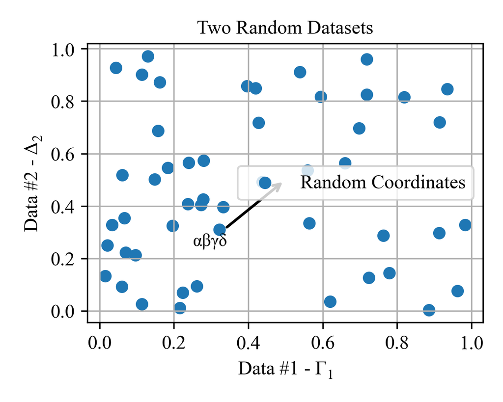

Figure 2: This Figure was generated using `numpy` and `matplotlib`.

[`numpy`](https://www.numpy.org) and [`matplotlib`](https://www.matplotlib.org) are powerful python modules for mathematical computing and plot generation. The following example shows how to generate Fig. 2 using `numpy` and `matplotlib` and include it into the document.

**Example**

```python
    import numpy as np
    import matplotlib.pyplot as plt
    GREEK = lambda A: chr(ord(u"\u0391") + ord(A) - ord("A"))
    greek = lambda a: chr(ord(u"\u03b1") + ord(a) - ord("a"))
    cm2inch = lambda xy: tuple(i/2.54 for i in xy)
    fontsize = int(fontsize[:-2]) # convert to int
    figsize = cm2inch(figsize) # convert from cm to inch
    params = {
        'figure.figsize': figsize,
        'legend.fontsize': fontsize,
        'axes.labelsize': fontsize,
        'axes.titlesize': fontsize,
        'xtick.labelsize': fontsize,
        'ytick.labelsize': fontsize,
        'font.family': 'Times New Roman'
    }
    plt.rcParams.update(params)
    x = np.random.rand(50)
    y = np.random.rand(50)
    plt.figure()
    plt.scatter(x, y, label="Random Coordinates")
    text = "".join([greek(i) for i in ["a", "b", "c", "d"]])
    plt.annotate(text, xy=(0.5,0.5), xytext=(0.25,0.25),
        arrowprops=dict(arrowstyle='->',lw=1.5))
    plt.title("Two Random Datasets")
    plt.xlabel(r"Data #1 - $\mathdefault{%s_1}$" % GREEK("C"))
    plt.ylabel(r"Data #2 - $\mathdefault{%s_2}$" % GREEK("D"))
    plt.grid()
    plt.legend()
    plt.tight_layout()
    plt.savefig("build/figure1.png", dpi=figdpi)
    plt.close("all")
```

```markdown
![This Figure was generated using `numpy`
and `matplotlib`.](figure1.png){#fig:figure1}
```

## 7.3 Generate a Sequence of Figures on-the-fly

This section illustrates how a sequence of complex figures can be generated using `numpy` and `matplotlib` and how the figures are formatted using python and referenced using `marky`.

Suppose one experiment which can be run in four different setups with different values for *λ*=

1. $125.33$nm, (2) $250.66$nm, (3) $375.99$nm, (4) $501.32$nm. Each run of the experiment using setup (1)–(4), two additional parameters *ε* and *α* are varried between $10.2…30.6%$ and $0.1…0.3$Hz respectively.

The results of the experiments for the setups (1)–(4) are summarized in the Fig. 3, 4, 5 and 6.

**Example**

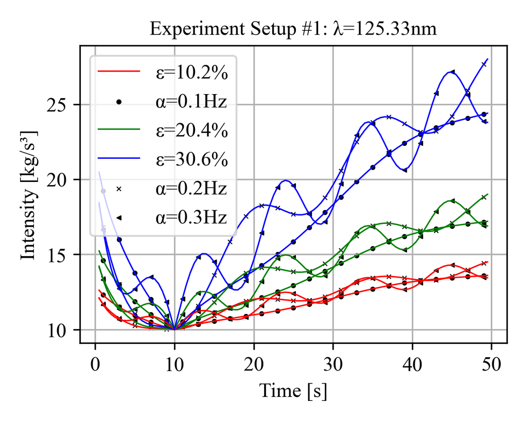

Figure 3: This is the result of the experiment according to the setup #1 with *λ* = 125.33nm. The parameters *ε* and *α* are varried between $10.2…30.6%$ and $0.1…0.3$Hz respectively.

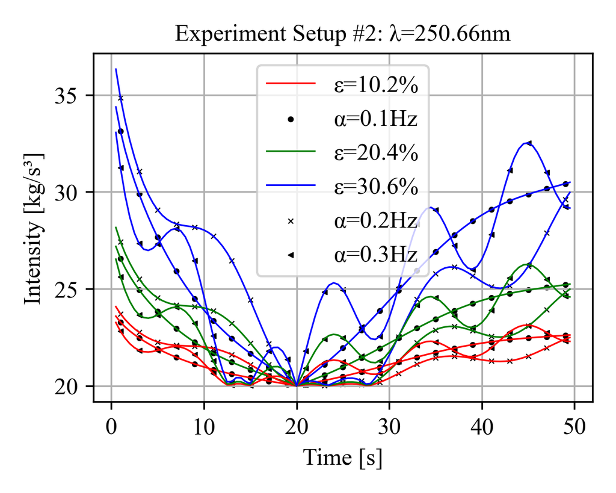

Figure 4: This is the result of the experiment according to the setup #2 with *λ* = 250.66nm. The parameters *ε* and *α* are varried between $10.2…30.6%$ and $0.1…0.3$Hz respectively.

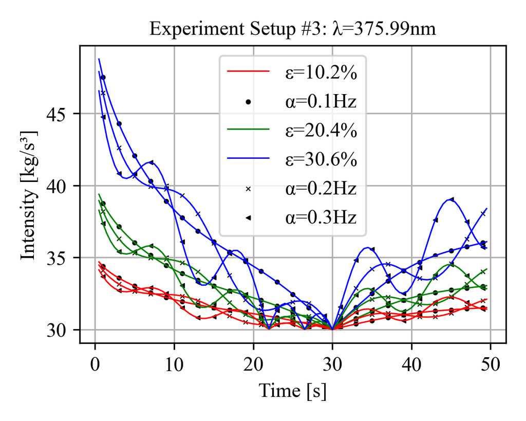

Figure 5: This is the result of the experiment according to the setup #3 with *λ* = 375.99nm. The parameters *ε* and *α* are varried between $10.2…30.6%$ and $0.1…0.3$Hz respectively.

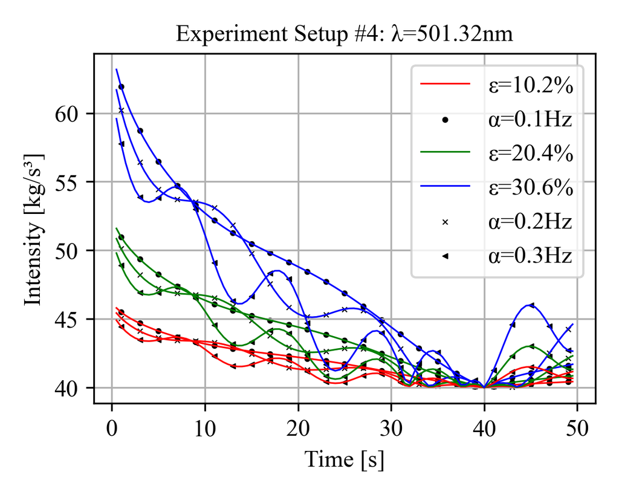

Figure 6: This is the result of the experiment according to the setup #4 with *λ* = 501.32nm. The parameters *ε* and *α* are varried between $10.2…30.6%$ and $0.1…0.3$Hz respectively.

```python
    n = 100
    alpha = u"\u03b1"
    epsilon = u"\u03b5"
    lamda = u"\u03bb"
    f = lambda x, a, b: a*(np.sqrt(x)+b*np.sin(x*b))
    g = lambda x, a ,b, c: np.fabs(f(x, a, b) - f(c, a, b)) + c
    dat = np.zeros((n-1, 3, 3, 4), dtype=np.float32)
    cols = ["red", "green", "blue"]
    mark = ["o", "x", "<"]
    x = np.array([50.*x/n for x in range(1, n)], dtype=np.float32)
    for k, c in enumerate([10., 20., 30., 40.]):
        for i, a in enumerate([1, 2, 4]):
            for j, b in enumerate([0.2, 0.4, 0.6]):
                dat[:, i, j, k] = g(x, a, b, c)
        plt.figure()
        for j in range(3):
            for i in range(3):
                label_i = "%s=%.1f%%" % (epsilon, (i+1)*10.2) \
                    if j == 0 else None
                label_j = "%s=%.1fHz" % (alpha, (j+1)/10.) \
                    if i == 0 else None
                y = dat[:, i, j, k].flatten()
                plt.plot(x, y, color=cols[i], lw=0.75, label=label_i)
                plt.scatter(x[1::4], y[1::4], color="black",
                    marker=mark[j], lw=0.5, s=5, label=label_j)
        k = k + 1
        kval = k*125.33
        plt.title("Experiment Setup #%d: %s=%.2fnm" % (k, lamda, kval))
        plt.xlabel("Time [s]")
        plt.ylabel("Intensity [kg/s³]")
        plt.grid()
        plt.legend()
        plt.tight_layout()
        plt.savefig("build/figure2-%d.png" % k, dpi=figdpi)
        plt.close("all")
        __(f"""
            ![This is the result of the experiment according
            to the setup #{k} with ${lamda}={kval}$nm. The parameters
            ${epsilon}$ and ${alpha}$ are varried between
            $10.2\ldots30.6\%$ and $0.1\ldots0.3$Hz
            respectively.](figure2-{k}.png){{#fig:figure2_{k}}}

        """)
```

*Thanks for reading, please try `marky`.*

# References

Muller, Peter. 1993. “The Title of the Work.” *The Name of the Journal* 4 (2): 201–13.